# Tulips

Stat 341 — Spring 2017

### The data

```r
library(rethinking)
data(tulips)
Tulips <-
  tulips %>%
  mutate(
    shade.c = shade - mean(shade),
    water.c = water - mean(water)
  )
glimpse(Tulips)
```

```
## Observations: 27
## Variables: 6
## $ bed     <fctr> a, a, a, a, a, a, a, a, a, b, b, b, b, b, b, b, b, b,...
## $ water   <int> 1, 1, 1, 2, 2, 2, 3, 3, 3, 1, 1, 1, 2, 2, 2, 3, 3, 3, ...
## $ shade   <int> 1, 2, 3, 1, 2, 3, 1, 2, 3, 1, 2, 3, 1, 2, 3, 1, 2, 3, ...
## $ blooms  <dbl> 0.00, 0.00, 111.04, 183.47, 59.16, 76.75, 224.97, 83.7...
## $ shade.c <dbl> -1, 0, 1, -1, 0, 1, -1, 0, 1, -1, 0, 1, -1, 0, 1, -1, ...
## $ water.c <dbl> -1, -1, -1, 0, 0, 0, 1, 1, 1, -1, -1, -1, 0, 0, 0, 1, ...
```

## Two Models

**How do these models differ?**

- What might lead you to fit one but not the other?
- How would you compare them to decide which model is “better” if you fit both?

```r
m7.6 <- map(
  alist(
    blooms ~ dnorm(mu, sigma),
    mu <- a + bW * water + bS * shade,
    c(a, bW, bS) ~ dnorm(0, 100),
    sigma ~ dunif(0, 100)
  ),
  data = Tulips,
  method = "Nelder-Mead", control = list(maxit = 1e4)
)
m7.7 <- map(
  alist(
    blooms ~ dnorm(mu, sigma),
    mu <- a + bW * water + bS * shade + bWS * water * shade,
    c(a, bW, bS, bWS) ~ dnorm(0, 100),
    sigma ~ dunif(0, 100)
  ),
  data = Tulips,
  method = "Nelder-Mead", control = list(maxit = 1e4)
)
```

## 9 groups, 9 parameters?

In this set-up, there are only 9 possible combinations of water and shade.

```r
tally(shade ~ water, data = Tulips)
```

```
##      water
## shade 1 2 3
##     1 3 3 3
##     2 3 3 3
##     3 3 3 3
```

**What predictions do our previous two models give for each of the 9 combinations?**

```r
coeftab(m7.6, m7.7)
```

```
##       m7.6    m7.7
## a       53.48  -84.50
## bW      76.36  151.16
## bS     -38.93   35.09
## sigma   57.38   46.24
## bWS        NA  -39.59
## nobs       27      27
```

**Design a model that has 9 parameters, one for each combination.**

- There is more than one way to do this, choose a way that makes the parameters as interpretable as you can.

**What are the advantages/disadvantages of such a model?**

**In what sense is this a “model with interaction”?**

- How can you tell by looking at the paramters whether this is a large or small “interaction effect”?

```r
m7.7a <- map(
  alist(
    blooms ~ dnorm(mu, sigma),
    mu <- bS[shade] + bW[water] +
      gamma22 * (shade == 2) * (water == 2) +
      gamma23 * (shade == 2) * (water == 3) +
      gamma32 * (shade == 3) * (water == 2) +
      gamma33 * (shade == 3) * (water == 3),
    bS[shade] ~ dnorm(100, 100),
    bW[water] ~ dnorm(100, 100),
    c(gamma22, gamma23, gamma32, gamma33) ~ dnorm(0, 100),
    sigma ~ dunif(0, 100)
  ),
  data = Tulips,
  method = "Nelder-Mead", control = list(maxit = 1e4)
)
coef(m7.7a)
```

```
##      bS[1]      bS[2]      bS[3]      bW[1]      bW[2]      bW[3]
##   99.26873   85.10039  116.47006  -49.31869   99.50449  182.57226
##    gamma22    gamma23    gamma32    gamma33      sigma
##  -72.03551  -91.87479 -134.91164 -159.42271   41.74920
```

### Six Degrees of freedom

A better way to see the strength of the interaction effect is to fit a model without interaction terms.

**Design a model with 6 parameters that is the previosu model “minus interaction.”**

- Reparameterize if that is more convenient.

```r
m7.7b <- map(
  alist(
    blooms ~ dnorm(mu, sigma),
    mu <- bS[shade] + bW[water],
    bS[shade] ~ dnorm(100, 100),
    bW[water] ~ dnorm(100, 100),
    sigma ~ dunif(0, 100)
  ),
  data = Tulips,
  method = "Nelder-Mead", control = list(maxit = 1e4)
)
coef(m7.7b)
```

```
##     bS[1]     bS[2]     bS[3]     bW[1]     bW[2]     bW[3]     sigma
## 118.77558  41.88688  32.22653 -10.01722  69.88013 134.02981  55.59777
```

```r
compare(m7.6, m7.7, m7.7a, m7.7b)
```

```
##        WAIC pWAIC dWAIC weight    SE  dSE
## m7.7  295.9   6.0   0.0   0.95  9.87   NA
## m7.7a 302.3  11.8   6.3   0.04 10.43 5.29
## m7.6  305.5   5.1   9.5   0.01  8.78 5.94
## m7.7b 310.0   7.9  14.1   0.00  9.07 8.52
```

```r
compare(m7.6, m7.7)
```

```
##       WAIC pWAIC dWAIC weight   SE  dSE
## m7.7 295.8   5.9   0.0   0.99 9.82   NA
## m7.6 305.6   5.1   9.7   0.01 8.83 5.86
```

```r
m7.8 <- map(
  alist(
    blooms ~ dnorm(mu, sigma),
    mu <- a + bW * water.c + bS * shade.c,
    a ~ dnorm(130, 100),
    c(bW, bS) ~ dnorm(0, 100),
    sigma ~ dunif(0, 100)
  ),
  data = Tulips,
  start = list( a = mean(Tulips$blooms), bW = 0, bS = 0, sigma = sd(Tulips$blooms))
)
m7.9 <- map(
  alist(
    blooms ~ dnorm(mu, sigma),
    mu <- a + bW * water.c + bS * shade.c + bWS * water.c * shade.c,
    a ~ dnorm(130, 100),
    c(bW, bS, bWS) ~ dnorm(0, 100),
    sigma ~ dunif(0, 100)
  ),
  data = Tulips,
  start = list(a = mean(Tulips$blooms), bW = 0, bS = 0, bWS = 0,
               sigma = sd(Tulips$blooms))
)
coeftab(m7.8, m7.9)
```

```
##       m7.8    m7.9
## a      129.00  129.01
## bW      74.22   74.96
## bS     -40.74  -41.14
## sigma   57.35   45.22
## bWS        NA  -51.87
## nobs       27      27
```

**What does each model predict for a flower bed that gets two units of sun and two units of water?**

#### R Code 7.26

```r
k <- coef(m7.9); k
```

```
##         a        bW        bS       bWS     sigma
## 129.00797  74.95946 -41.14054 -51.87265  45.22497
```

```r
(k["a"] + k["bW"] * 0 + k["bS"] * 0 + k["bWS"] * 0 * 0) %>% setNames("mu.S0W0")
```

```
## mu.S0W0
## 129.008
```

#### R Code 7.27

```r
precis(m7.9)
```

```
##         Mean StdDev   5.5%  94.5%
## a     129.01   8.67 115.15 142.87
## bW     74.96  10.60  58.02  91.90
## bS    -41.14  10.60 -58.08 -24.20
## bWS   -51.87  12.95 -72.57 -31.18
## sigma  45.22   6.15  35.39  55.06
```

#### R Code 7.28

```r
Blooms_predict <-
  expand.grid(shade.c = -1:1, water.c = -1:1)

m7.8.link <- link(m7.8, data = Blooms_predict)
```

```
## [ 100 / 1000 ]
[ 200 / 1000 ]
[ 300 / 1000 ]
[ 400 / 1000 ]
[ 500 / 1000 ]
[ 600 / 1000 ]
[ 700 / 1000 ]
[ 800 / 1000 ]
[ 900 / 1000 ]
[ 1000 / 1000 ]
```

```r
m7.9.link <- link(m7.9, data = Blooms_predict)
```

```
## [ 100 / 1000 ]
[ 200 / 1000 ]
[ 300 / 1000 ]
[ 400 / 1000 ]
[ 500 / 1000 ]
[ 600 / 1000 ]
[ 700 / 1000 ]
[ 800 / 1000 ]
[ 900 / 1000 ]
[ 1000 / 1000 ]
```

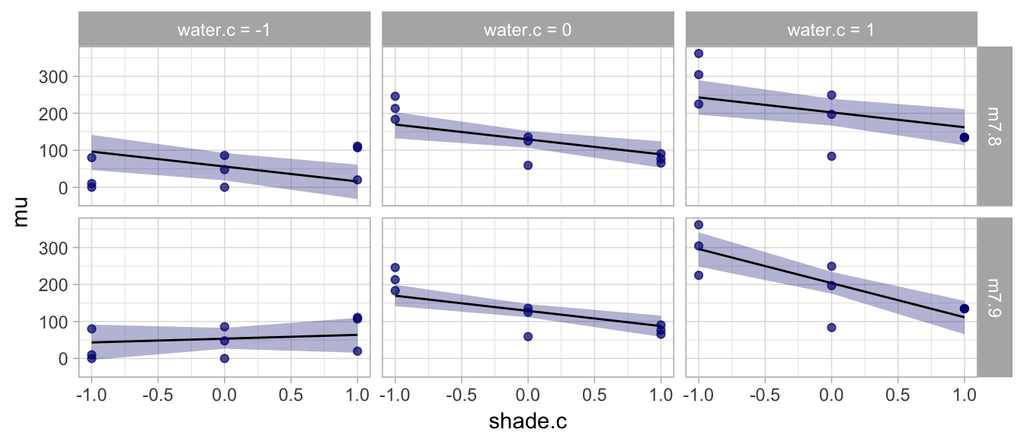

```r
# We can put two models together above and below or side by side.
# Above/below let's us use facets to compare the model predictions.

Blooms_predict <-
  bind_rows(
    Blooms_predict %>%
      mutate(
        mu = apply(m7.8.link, 2, mean),
        lo = apply(m7.8.link, 2, PI, 0.97)[1,],
        hi = apply(m7.8.link, 2, PI, 0.97)[2,],
        model = "m7.8"
      ),
    Blooms_predict %>%
      mutate(
        mu = apply(m7.9.link, 2, mean),
        lo = apply(m7.9.link, 2, PI, 0.97)[1,],
        hi = apply(m7.9.link, 2, PI, 0.97)[2,],
        model = "m7.9"
      )
  )

gf_ribbon(lo + hi ~ shade.c, data = Blooms_predict, fill = "navy")  %>%
gf_line(mu ~ shade.c, data = Blooms_predict)  %>%
gf_point(blooms ~ shade.c, data = Tulips, alpha = 0.7, color = "navy") %>%
gf_facet_grid(model ~ paste0("water.c = ", water.c))
```

#### R Code 7.29

```r
m7.x <- lm(blooms ~ water + shade + water:shade, data = Tulips)
coef(m7.x)
```

```
## (Intercept)       water       shade water:shade
##  -150.81074   181.50500    64.10056   -52.85167
```

#### R Code 7.30

```r
# short hand notation
m7.x <- lm(blooms ~ water*shade, data = Tulips)
coef(m7.x)
```

```
## (Intercept)       water       shade water:shade
##  -150.81074   181.50500    64.10056   -52.85167
```

#### R Code 7.31

```r
m7.x <- lm(blooms ~ water*shade - shade, data = Tulips)
coef(m7.x)
```

```
## (Intercept)       water water:shade
##   -22.60963   126.56167   -25.38000
```

#### R Code 7.32

```r
m7.x <- lm(blooms ~ water*shade*bed, data = Tulips)
coef(m7.x)
```

```
##      (Intercept)            water            shade             bedb
##      -186.253333       155.971667        86.246667       137.938889
##             bedc      water:shade       water:bedb       water:bedc
##       -31.611111       -50.265000        11.911667        64.688333
##       shade:bedb       shade:bedc water:shade:bedb water:shade:bedc
##       -75.431667         8.993333         8.640000       -16.400000
```

#### R Code 7.33

```r
x <- z <- w <- 1
colnames(model.matrix( ~ x * z * w))
```

```
## [1] "(Intercept)" "x"           "z"           "w"           "x:z"
## [6] "x:w"         "z:w"         "x:z:w"
```

#### R Code 7.34

```r
data(nettle)
Nettle <-
  nettle %>%
  mutate(lang.per.cap = num.lang / k.pop)
head(Nettle, 3)
```

```
##     country num.lang    area k.pop num.stations mean.growing.season
## 1   Algeria       18 2381741 25660          102                6.60
## 2    Angola       42 1246700 10303           50                6.22
## 3 Australia      234 7713364 17336          134                6.00
##   sd.growing.season lang.per.cap
## 1              2.29 0.0007014809
## 2              1.87 0.0040764826
## 3              4.17 0.0134979234
```